# Modeling Political Risk Data

- COMPSS 224B: Quantitative Political Risk
- Authors: Iris Malone and Mark Rosenberg
- Last Revised: 2 May 2025

This notebook will walk you through some basic non-parametric methods. This includes:

- Class Imbalance
- Tree Models
- Hyperparameter tuning/grid search

```python
import numpy as np
import pandas as pd
idx = pd.IndexSlice
import matplotlib.pyplot as plt
import re
import os
```

# Inspecting Your Data

```python
singhway = pd.read_csv("singhway.csv")
```

Singh and Way (2004) examine the correlates of nuclear proliferation from 1945-2000. They want to understand why some states acquire a nuclear weapon (in a given year) versus others.

```python
singhway.columns
```

```
Index(['country', 'cowcc', 'year', 'risk', 'level', 'explore', 'pursue',
       'acquire', 'gdpcap', 'g2', 'industry1', 'rivalry', 'disputes', 'allies',
       'democracy', 'democratization', 'percentdems', 'openness',
       'liberalization'],
      dtype='object')
```

Correlates include:

- Technological determinants:
  - gdp/cap,
  - gdp/cap^2,
  - industrial capacity index
- External determinants:
  - rivalry,
  - militarized dispute involvement,
- Internal determinants:
  - democracy,
  - democratization,
  - democratic ('good') neighborhood,
  - economic openness (exports as percent of gdp),
  - liberalization (change in trade ratios)

### Correlations

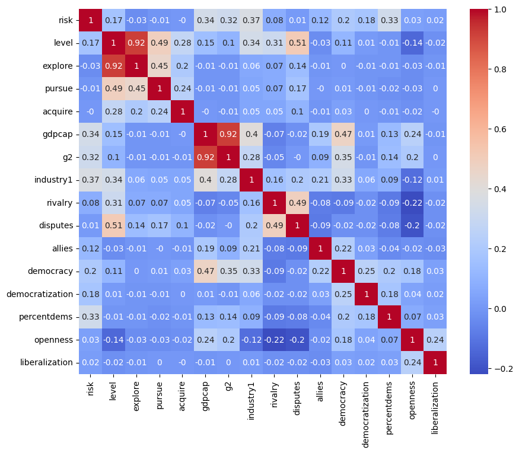

```python
import matplotlib.pyplot as plt
#meta_cols = ['iso2c', 'year', 'level_0', 'index', 'country', 'iso3c', 'region']

corr_matrix = singhway.drop(['country', 'cowcc', 'year'], axis=1).corr().round(2)
import seaborn as sns
plt.figure(figsize=(10, 8))
sns.heatmap(corr_matrix, cmap="coolwarm", annot=True)
```

### Distributions

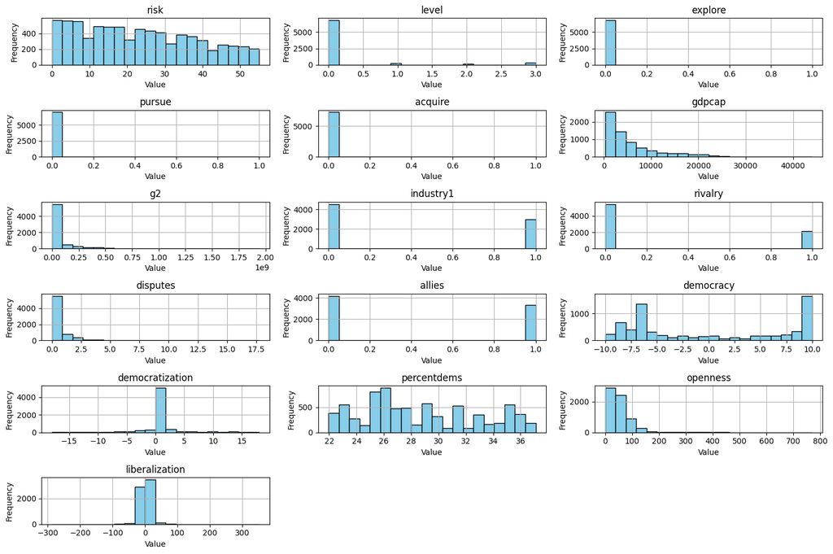

```python
import pandas as pd
import matplotlib.pyplot as plt
import seaborn as sns
def plot_histograms(df, bins=20, figsize=(15, 10), color='skyblue'):
    """
    Plots histograms for all numeric columns in the DataFrame.
    """
    numeric_cols = df.select_dtypes(include='number').columns
    num_cols = len(numeric_cols)

    if num_cols == 0:
        print("No numeric columns to plot.")
        return

    cols = 3  # number of plots per row
    rows = (num_cols + cols - 1) // cols

    plt.figure(figsize=figsize)
    for i, col in enumerate(numeric_cols, 1):
        plt.subplot(rows, cols, i)
        df[col].hist(bins=bins, color=color, edgecolor='black')
        plt.title(col)
        plt.xlabel('Value')
        plt.ylabel('Frequency')

    plt.tight_layout()
    plt.show()
plot_histograms(singhway.drop(['country', 'cowcc', 'year'], axis=1))
```

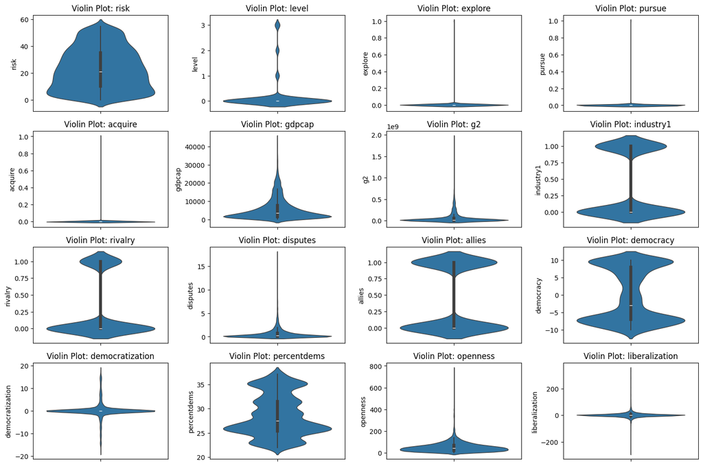

```python
import matplotlib.pyplot as plt
import seaborn as sns
import pandas as pd

def plot_violin_plot(df, figsize=(15, 10)):
    """
    Generates side-by-side violin plots for each numeric column in a DataFrame.

    Args:
        df (pd.DataFrame): The input DataFrame.
        figsize (tuple): Size of the entire figure.
    """
    numeric_cols = df.select_dtypes(include='number').columns
    num_cols = len(numeric_cols)

    if num_cols == 0:
        print("No numeric columns to plot.")
        return

    cols = 4  # plots per row
    rows = (num_cols + cols - 1) // cols

    fig, axes = plt.subplots(rows, cols, figsize=figsize)
    axes = axes.flatten()  # flatten in case of single row

    for i, col in enumerate(numeric_cols):
        sns.violinplot(y=df[col], ax=axes[i], inner='box', linewidth=1)
        axes[i].set_title(f'Violin Plot: {col}')
        axes[i].set_ylabel(col)

    # Remove empty subplots if any
    for j in range(i + 1, len(axes)):
        fig.delaxes(axes[j])

    plt.tight_layout()
    plt.show()
plot_violin_plot(singhway.drop(['country', 'cowcc', 'year'], axis=1))
```

## Total Data

Singh and Way use a common country identifier known as 'Correlates of War' country code. We will translate it to more common iso2 format and add region identifiers

```python
import country_converter as coco
cc = coco.CountryConverter()

# Add ISO 2-character and 3-character codes using src Gleditsch and Ward codes (pretty close)
singhway['iso2c'] = cc.convert(names=singhway['cowcc'], src='GWcode', to='ISO2')
singhway['iso3c'] = cc.convert(names=singhway['cowcc'], src='GWcode', to='ISO3')
singhway['region'] = cc.convert(names=singhway['iso2c'], src='ISO2', to='UNregion')

# Preview the result
print(singhway[['cowcc', 'iso2c', 'iso3c']].head())
```

[output not shown]

[output cut: 27293 more lines]

[output not shown]

```
   cowcc iso2c iso3c
0      2    US   USA
1      2    US   USA
2      2    US   USA
3      2    US   USA
4      2    US   USA
```

```python
#drop if no label (country converter added them on)
singhway = singhway.dropna(subset=['country'])
singhway.set_index(['iso2c', 'year'])
```

| iso2c | year | country | cowcc | risk | level | explore | pursue | acquire | gdpcap | g2 | industry1 | rivalry | disputes | allies | democracy | democratization | percentdems | openness | liberalization | iso3c | region |
| --- | --- | --- | --- | --- | --- | --- | --- | --- | --- | --- | --- | --- | --- | --- | --- | --- | --- | --- | --- | --- | --- |
| US | 1945 | USA | 2 | 0.0 | 3.0 | 1.0 | 1.0 | 1.0 | 10598.0 | 112000000.0 | 1.0 | 1.0 | 6.0 | 0.0 | 10.0 | 0.0 | 29.170000 | 7.0 | 1.0 | USA | Northern America |
|  | 1946 | USA | 2 | 1.0 | 3.0 | NaN | NaN | NaN | 10621.0 | 113000000.0 | 1.0 | 1.0 | 5.0 | 0.0 | 10.0 | 0.0 | 30.139999 | 7.0 | 1.0 | USA | Northern America |
|  | 1947 | USA | 2 | 2.0 | 3.0 | NaN | NaN | NaN | 10644.0 | 113000000.0 | 1.0 | 1.0 | 4.0 | 0.0 | 10.0 | 0.0 | 28.379999 | 7.0 | 1.0 | USA | Northern America |
|  | 1948 | USA | 2 | 3.0 | 3.0 | NaN | NaN | NaN | 10665.0 | 114000000.0 | 1.0 | 1.0 | 3.0 | 0.0 | 10.0 | 0.0 | 29.110001 | 8.0 | 1.0 | USA | Northern America |
|  | 1949 | USA | 2 | 4.0 | 3.0 | NaN | NaN | NaN | 10686.0 | 114000000.0 | 1.0 | 1.0 | 3.0 | 0.0 | 10.0 | 0.0 | 28.750000 | 8.0 | 1.0 | USA | Northern America |
| ... | ... | ... | ... | ... | ... | ... | ... | ... | ... | ... | ... | ... | ... | ... | ... | ... | ... | ... | ... | ... | ... |
| WS | 1993 | Western Samoa | 990 | 17.0 | 0.0 | 0.0 | 0.0 | 0.0 | NaN | NaN | 0.0 | 0.0 | 0.0 | 0.0 | NaN | NaN | 35.000000 | NaN | NaN | WSM | Polynesia |
|  | 1994 | Western Samoa | 990 | 18.0 | 0.0 | 0.0 | 0.0 | 0.0 | NaN | NaN | 0.0 | 0.0 | 0.0 | 0.0 | NaN | NaN | 35.000000 | NaN | NaN | WSM | Polynesia |
|  | 1995 | Western Samoa | 990 | 19.0 | 0.0 | 0.0 | 0.0 | 0.0 | NaN | NaN | 0.0 | 0.0 | 0.0 | 0.0 | NaN | NaN | 35.220001 | NaN | NaN | WSM | Polynesia |
|  | 1996 | Western Samoa | 990 | 20.0 | 0.0 | 0.0 | 0.0 | 0.0 | NaN | NaN | 0.0 | 0.0 | 0.0 | 0.0 | NaN | NaN | 37.110001 | NaN | NaN | WSM | Polynesia |
|  | 1997 | Western Samoa | 990 | 21.0 | 0.0 | 0.0 | 0.0 | 0.0 | NaN | NaN | 0.0 | 0.0 | 0.0 | 0.0 | NaN | NaN | 35.849998 | NaN | NaN | WSM | Polynesia |

7881 rows × 20 columns

```python
singhway.describe()
```

|  | cowcc | year | risk | level | explore | pursue | acquire | gdpcap | g2 | industry1 | rivalry | disputes | allies | democracy | democratization | percentdems | openness | liberalization |
| --- | --- | --- | --- | --- | --- | --- | --- | --- | --- | --- | --- | --- | --- | --- | --- | --- | --- | --- |
| count | 7881.000000 | 7881.000000 | 7566.000000 | 7516.000000 | 6798.000000 | 7044.000000 | 7248.000000 | 6750.000000 | 6.750000e+03 | 7549.000000 | 7566.000000 | 7044.000000 | 7499.000000 | 6891.000000 | 6892.000000 | 7566.000000 | 6724.000000 | 6662.000000 |
| mean | 435.145032 | 1976.185256 | 22.989294 | 0.205828 | 0.003678 | 0.002413 | 0.001380 | 5784.280148 | 6.924475e+07 | 0.397801 | 0.279672 | 0.646013 | 0.442059 | -0.274126 | 0.257110 | 28.632207 | 53.377097 | 2.161187 |
| std | 262.596505 | 15.297438 | 15.291649 | 0.678398 | 0.060536 | 0.049071 | 0.037121 | 5982.849660 | 1.467016e+08 | 0.489476 | 0.448868 | 1.251228 | 0.496665 | 7.594888 | 3.775987 | 4.264814 | 48.227726 | 19.743939 |
| min | 2.000000 | 1945.000000 | 0.000000 | 0.000000 | 0.000000 | 0.000000 | 0.000000 | 281.000000 | 7.896100e+04 | 0.000000 | 0.000000 | 0.000000 | 0.000000 | -10.000000 | -18.000000 | 21.950001 | 0.030000 | -287.090000 |
| 25% | 210.000000 | 1964.000000 | 10.000000 | 0.000000 | 0.000000 | 0.000000 | 0.000000 | 1487.250000 | 2.211913e+06 | 0.000000 | 0.000000 | 0.000000 | 0.000000 | -7.000000 | 0.000000 | 25.350000 | 23.309999 | -3.230000 |
| 50% | 436.000000 | 1977.000000 | 21.000000 | 0.000000 | 0.000000 | 0.000000 | 0.000000 | 3570.000000 | 1.275000e+07 | 0.000000 | 0.000000 | 0.200000 | 0.000000 | -3.000000 | 0.000000 | 27.459999 | 44.024999 | 1.260000 |
| 75% | 663.000000 | 1990.000000 | 35.000000 | 0.000000 | 0.000000 | 0.000000 | 0.000000 | 7602.000000 | 5.780000e+07 | 1.000000 | 1.000000 | 0.800000 | 1.000000 | 8.000000 | 0.000000 | 31.450001 | 69.522498 | 6.730000 |
| max | 990.000000 | 2000.000000 | 55.000000 | 3.000000 | 1.000000 | 1.000000 | 1.000000 | 44048.000000 | 1.940000e+09 | 1.000000 | 1.000000 | 17.750000 | 1.000000 | 10.000000 | 18.000000 | 37.110001 | 770.479980 | 352.260010 |

## Missing Data

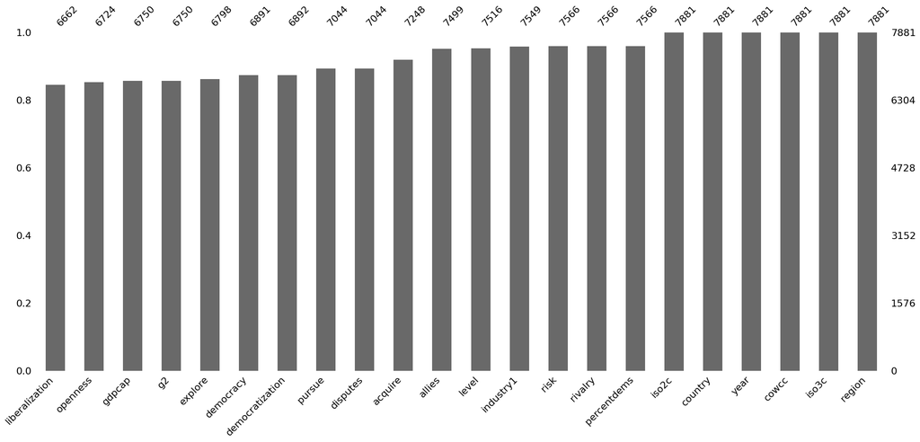

```python
import missingno as msno
msno.bar(singhway, sort="ascending")
```

*Commentary* It looks like we are missing data on liberalization, economic openness, and gdp

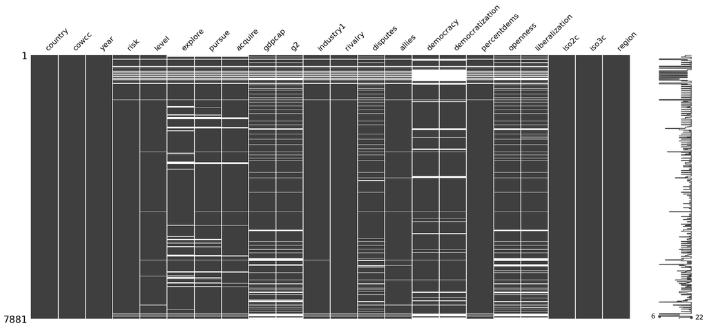

```python
msno.matrix(singhway)
```

*commentary*: Lots more missingness here which we can see in the matrix

```python
from itables import init_notebook_mode
init_notebook_mode(all_interactive=True)
from itables import show

def missing_values_table(df):
    mis_val = df.isnull().sum()
    mis_val_percent = 100 * df.isnull().sum() / len(df)
    mis_val_table = pd.concat([mis_val, mis_val_percent], axis=1)
    mis_val_table_ren_columns = mis_val_table.rename(
    columns = {0 : 'Missing Values', 1 : '% of Total Values'})
    mis_val_table_ren_columns = mis_val_table_ren_columns[
        mis_val_table_ren_columns.iloc[:,1] != 0].sort_values(
    '% of Total Values', ascending=False).round(1)

    print ("Your selected dataframe has " + str(df.shape[1]) + " columns.\n"
        "There are " + str(mis_val_table_ren_columns.shape[0]) +
            " columns that have missing values.")

    return mis_val_table_ren_columns

# I also often use time series cross-sectional specific functions
# to use in your own work modify by unit and date vars
def missing_country_table(df):
    df.reset_index(inplace=True)
    #df.drop(columns=['index', 'level_0'])
    mis_val = df.groupby(['iso2c']).apply(lambda x: x.isna().sum())
    mis_val_table = pd.concat([mis_val], axis=1)
    return mis_val_table

#we'll add a new tool to inspect time series data
def missing_year_table(df):
    df.reset_index(inplace=True)
    #df.drop(columns=['index', 'level_0'])
    mis_val = df.groupby(['year']).apply(lambda x: x.isna().sum())
    mis_val_table = pd.concat([mis_val], axis=1)
    return mis_val_table
```

```python
missing_values_table(singhway)
#we are missing 15% of all liberalization observations
```

```
Your selected dataframe has 22 columns.
There are 16 columns that have missing values.
```

Missing Values

% of Total Values

[figure not shown]

Loading ITables v2.3.0 from the `init_notebook_mode` cell... (need [help](https://mwouts.github.io/itables/troubleshooting.html)?)

*Commentary* This looks like a good case of data missing not at random. Why? First, GDP data is missing, but that is we know this data is available from other cross-national datasets (e.g. World Development). Second, text tells us openness and liberalization data are based on GDP-dependent calculations (e.g. openness is exports plus imports as a share of GDP). So the actual solution here is to go out and fill in these gaps and redo the calculations. See: https://www.kns.org/files/pre_paper/43/20S-313-%EA%B9%80%EC%B2%A0%EB%AF%BC.pdf

```python
missing_country_table(singhway)
```

index

country

cowcc

year

risk

level

explore

pursue

acquire

gdpcap

g2

industry1

rivalry

disputes

allies

democracy

democratization

percentdems

openness

liberalization

iso2c

iso3c

region

iso2c

[figure not shown]

Loading ITables v2.3.0 from the `init_notebook_mode` cell... (need [help](https://mwouts.github.io/itables/troubleshooting.html)?)

```python
missing_year_table(singhway)
```

level_0

index

country

cowcc

year

risk

level

explore

pursue

acquire

gdpcap

g2

industry1

rivalry

disputes

allies

democracy

democratization

percentdems

openness

liberalization

iso2c

iso3c

region

year

[figure not shown]

Loading ITables v2.3.0 from the `init_notebook_mode` cell... (need [help](https://mwouts.github.io/itables/troubleshooting.html)?)

There is second set of missingness (MAR). This is mostly true of the outcome variable which is purposely censored.

```python
singhway.loc[idx['US':]]
```

level_0

index

country

cowcc

year

risk

level

explore

pursue

acquire

gdpcap

g2

industry1

rivalry

disputes

allies

democracy

democratization

percentdems

openness

liberalization

iso2c

iso3c

region

[figure not shown]

Loading ITables v2.3.0 from the `init_notebook_mode` cell... (need [help](https://mwouts.github.io/itables/troubleshooting.html)?)

*Commentary:* Data for US is censored after 1945 because that's when it acquired a nuclear weapon! Data for states that gain independence is also missing before independence (e.g. Malaysia, Oman, etc) This is perfect example of Missing at Random (censored before/after a given date).

```python
idx = pd.IndexSlice
singhway = singhway[singhway['iso2c'] != 'not found']

singhway = singhway.set_index(['iso2c', 'year']).sort_index()
#inspect the data
```

Solution: Go get the extra data to create a clean version of the dataset...

## Outcome Data

```python
singhway[['explore']].value_counts()
```

count

explore

[figure not shown]

Loading ITables v2.3.0 from the `init_notebook_mode` cell... (need [help](https://mwouts.github.io/itables/troubleshooting.html)?)

```python
singhway[['explore']].value_counts()/len(singhway['explore'])*100
```

count

explore

[figure not shown]

Loading ITables v2.3.0 from the `init_notebook_mode` cell... (need [help](https://mwouts.github.io/itables/troubleshooting.html)?)

```python
singhway[['pursue']].value_counts()
```

count

pursue

[figure not shown]

Loading ITables v2.3.0 from the `init_notebook_mode` cell... (need [help](https://mwouts.github.io/itables/troubleshooting.html)?)

```python
singhway[['acquire']].value_counts()
```

count

acquire

[figure not shown]

Loading ITables v2.3.0 from the `init_notebook_mode` cell... (need [help](https://mwouts.github.io/itables/troubleshooting.html)?)

# Preprocessing

### Go out into world, get data, fix

```python
sw = pd.read_csv("singhway_clean.csv")
```

## Transformations

*Commentary* Gdp and gdp2 are skewed so I will log transform. Others mostly look like binaries. I will leave disputes as is but could alternatively create a binary variable

```python
sw['log_gdpcap'] = np.log1p(sw['gdpcap'])
```

# Original Analysis

```python
import pandas as pd
from sklearn.linear_model import LogisticRegression
from sklearn.preprocessing import StandardScaler
from sklearn.metrics import classification_report
from sklearn.model_selection import train_test_split

# Define features and target
features = ['log_gdpcap',  'industry1', 'rivalry', 'disputes',
            'allies', 'democracy', 'democratization', 'percentdems',
            'openness', 'liberalization']
X = sw[features]
y = sw['explore']

# Fit logistic regression model
model = LogisticRegression(max_iter=1000)
model.fit(X, y)

# Show model summary equivalent
print("Coefficients:")
for feature, coef in zip(features, model.coef_[0]):
    print(f"{feature}: {coef:.4f}")
```

```
Coefficients:
log_gdpcap: 0.2810
industry1: 1.6038
rivalry: 1.1249
disputes: 0.2232
allies: -0.9547
democracy: 0.0326
democratization: -0.0310
percentdems: -0.0658
openness: -0.0238
liberalization: -0.0315
```

```python
import statsmodels.api as sm
# Add constant term (intercept)
X = sm.add_constant(X)

# Fit logistic regression (binomial family)
model = sm.Logit(y, X).fit()

# Print R-style summary with p-values, coef, std err, etc.
print(model.summary())
```

```
Optimization terminated successfully.
         Current function value: 0.023150
         Iterations 11
                           Logit Regression Results
==============================================================================
Dep. Variable:                explore   No. Observations:                 5393
Model:                          Logit   Df Residuals:                     5382
Method:                           MLE   Df Model:                           10
Date:                Thu, 01 May 2025   Pseudo R-squ.:                  0.2162
Time:                        19:59:35   Log-Likelihood:                -124.85
converged:                       True   LL-Null:                       -159.29
Covariance Type:            nonrobust   LLR p-value:                 7.285e-11
===================================================================================
                      coef    std err          z      P>|z|      [0.025      0.975]
-----------------------------------------------------------------------------------
const              -6.3140      2.577     -2.450      0.014     -11.364      -1.264
log_gdpcap          0.2539      0.272      0.934      0.350      -0.279       0.787
industry1           2.2173      0.616      3.597      0.000       1.009       3.426
rivalry             1.3921      0.500      2.785      0.005       0.413       2.372
disputes            0.1926      0.073      2.648      0.008       0.050       0.335
allies             -1.3103      0.507     -2.587      0.010      -2.303      -0.317
democracy           0.0376      0.034      1.107      0.268      -0.029       0.104
democratization    -0.0398      0.060     -0.665      0.506      -0.157       0.077
percentdems        -0.0693      0.055     -1.271      0.204      -0.176       0.038
openness           -0.0248      0.010     -2.372      0.018      -0.045      -0.004
liberalization     -0.0312      0.018     -1.768      0.077      -0.066       0.003
===================================================================================

Possibly complete quasi-separation: A fraction 0.11 of observations can be
perfectly predicted. This might indicate that there is complete
quasi-separation. In this case some parameters will not be identified.
```

```python
# Train/test split (75% train, 25% test)
X_train, X_test, y_train, y_test = train_test_split(X, y, train_size=0.8, random_state=2025)

# Fit logistic regression
model = LogisticRegression(solver='lbfgs', max_iter=1000)
model.fit(X_train, y_train)

# Predict probabilities and classes
probs = model.predict_proba(X_test)[:, 1]
y_pred = (probs > 0.5).astype(int)

# Mean squared error (MSE on probability prediction)
mse = np.mean((y_test - probs) ** 2)
print(f"Test MSE: {mse:.4f}")

# Confusion matrix
from sklearn.metrics import confusion_matrix, classification_report

cm = confusion_matrix(y_test, y_pred)

# Extract metrics
tn, fp, fn, tp = cm.ravel()
accuracy = (tp + tn) / (tp + tn + fp + fn)
sensitivity = recall = tp / (tp + fn)  # recall
specificity = tn / (tn + fp)
precision = tp / (tp + fp)
f1 = 2 * precision * recall / (precision + recall)

# Print results
print("Confusion Matrix:")
print(cm)
# No Information Rate: proportion of majority class in y_test
nir = max(np.mean(y_test == 0), np.mean(y_test == 1))
print(f"No Information Rate (NIR): {nir:.3f}")
print(f"\nAccuracy:   {accuracy:.3f}")
print(f"Sensitivity (Recall): {sensitivity:.3f}")
print(f"Specificity: {specificity:.3f}")
print(f"Precision:   {precision:.3f}")
print(f"F1 Score:    {f1:.3f}")
```

```
Test MSE: 0.0079
Confusion Matrix:
[[1070    0]
 [   9    0]]
No Information Rate (NIR): 0.992

Accuracy:   0.992
Sensitivity (Recall): 0.000
Specificity: 1.000
Precision:   nan
F1 Score:    nan
```

*Commentary*: We can see that this model has no predictive value add

# Class Imbalance

When you have class imbalance you need to do feature selection before correcting for class imbalance If you try to correct after, then you'll have data leakage; the samples will be correlated which will artificially boost relative importance of indicators in sample

```python
#substitute log gdp and drop g2
features = ['log_gdpcap', 'industry1', 'rivalry', 'disputes',
            'allies', 'democracy', 'democratization', 'percentdems',
            'openness', 'liberalization']
sw = sw.set_index(['iso2c', 'year'])
sw = sw.dropna()
X = sw[features]
y = sw['explore']

X_train, X_test, y_train, y_test = train_test_split(X, y, train_size=0.8, random_state=2025)
```

```python
from imblearn.over_sampling import RandomOverSampler
from imblearn.under_sampling import RandomUnderSampler
```

### Oversampling

```python
ros = RandomOverSampler(random_state=2025)
X_train_resampled, y_train_resampled = ros.fit_resample(X_train, y_train)
```

```python
y_train.value_counts()
```

count

explore

[figure not shown]

Loading ITables v2.3.0 from the `init_notebook_mode` cell... (need [help](https://mwouts.github.io/itables/troubleshooting.html)?)

```python
y_train_resampled.value_counts() #oversampling creates 50/50
```

count

explore

[figure not shown]

Loading ITables v2.3.0 from the `init_notebook_mode` cell... (need [help](https://mwouts.github.io/itables/troubleshooting.html)?)

```python
# Re-fit logistic regression
model = LogisticRegression(solver='lbfgs', max_iter=1000)
model.fit(X_train_resampled, y_train_resampled)

# Predict probabilities and classes
probs = model.predict_proba(X_test)[:, 1]
y_pred = (probs > 0.5).astype(int)

# Mean squared error (MSE on probability prediction)
mse = np.mean((y_test - probs) ** 2)
print(f"Test MSE: {mse:.4f}")

# Confusion matrix
from sklearn.metrics import confusion_matrix, classification_report

cm = confusion_matrix(y_test, y_pred)

# Extract metrics
tn, fp, fn, tp = cm.ravel()
accuracy = (tp + tn) / (tp + tn + fp + fn)
sensitivity = recall = tp / (tp + fn)  # recall
specificity = tn / (tn + fp)
precision = tp / (tp + fp)
f1 = 2 * precision * recall / (precision + recall)

# Print results
print("Confusion Matrix:")
print(cm)
# No Information Rate: proportion of majority class in y_test
nir = max(np.mean(y_test == 0), np.mean(y_test == 1))
print(f"No Information Rate (NIR): {nir:.3f}")
print(f"\nAccuracy:   {accuracy:.3f}")
print(f"Sensitivity (Recall): {sensitivity:.3f}")
print(f"Specificity: {specificity:.3f}")
print(f"Precision:   {precision:.3f}")
print(f"F1 Score:    {f1:.3f}")
```

```
Test MSE: 0.1573
Confusion Matrix:
[[815 255]
 [  2   7]]
No Information Rate (NIR): 0.992

Accuracy:   0.762
Sensitivity (Recall): 0.778
Specificity: 0.762
Precision:   0.027
F1 Score:    0.052
```

**Commentary**: Very different results now! Although the overall accuracy has gone down, we suddenly have a non-zero TP rate.

### Undersampling

```python
rus = RandomUnderSampler(random_state=2025)
X_train_resampled, y_train_resampled = rus.fit_resample(X_train, y_train)
```

```python
y_train_resampled.value_counts() #downsampling (undersampling) reduces it to a very small number of observations
```

count

explore

[figure not shown]

Loading ITables v2.3.0 from the `init_notebook_mode` cell... (need [help](https://mwouts.github.io/itables/troubleshooting.html)?)

```python
# Re-fit logistic regression
model = LogisticRegression(solver='lbfgs', max_iter=1000)
model.fit(X_train_resampled, y_train_resampled)

# Predict probabilities and classes
probs = model.predict_proba(X_test)[:, 1]
y_pred = (probs > 0.5).astype(int)

# Mean squared error (MSE on probability prediction)
mse = np.mean((y_test - probs) ** 2)
print(f"Test MSE: {mse:.4f}")

# Confusion matrix
from sklearn.metrics import confusion_matrix, classification_report

cm = confusion_matrix(y_test, y_pred)

# Extract metrics
tn, fp, fn, tp = cm.ravel()
accuracy = (tp + tn) / (tp + tn + fp + fn)
sensitivity = recall = tp / (tp + fn)  # recall
specificity = tn / (tn + fp)
precision = tp / (tp + fp)
f1 = 2 * precision * recall / (precision + recall)

# Print results
print("Confusion Matrix:")
print(cm)
# No Information Rate: proportion of majority class in y_test
nir = max(np.mean(y_test == 0), np.mean(y_test == 1))
print(f"No Information Rate (NIR): {nir:.3f}")
print(f"\nAccuracy:   {accuracy:.3f}")
print(f"Sensitivity (Recall): {sensitivity:.3f}")
print(f"Specificity: {specificity:.3f}")
print(f"Precision:   {precision:.3f}")
print(f"F1 Score:    {f1:.3f}")
```

```
Test MSE: 0.1920
Confusion Matrix:
[[774 296]
 [  2   7]]
No Information Rate (NIR): 0.992

Accuracy:   0.724
Sensitivity (Recall): 0.778
Specificity: 0.723
Precision:   0.023
F1 Score:    0.045
```

**Commentary**: Like oversampling, undersampling also leads to an improvement in sensitivity. However, we might question how good this result is or if it's overfitting to the very few number of observations in the training data.

### SMOTE

```python
from imblearn.over_sampling import SMOTE
smote = SMOTE(random_state=2025)
X_train_smote, y_train_smote = smote.fit_resample(X_train, y_train)
```

```python
y_train_smote.value_counts()
```

count

explore

[figure not shown]

Loading ITables v2.3.0 from the `init_notebook_mode` cell... (need [help](https://mwouts.github.io/itables/troubleshooting.html)?)

```python
# Re-fit logistic regression
model = LogisticRegression(solver='lbfgs', max_iter=1000)
model.fit(X_train_smote, y_train_smote)

# Predict probabilities and classes
probs = model.predict_proba(X_test)[:, 1]
y_pred = (probs > 0.5).astype(int)

# Mean squared error (MSE on probability prediction)
mse = np.mean((y_test - probs) ** 2)
print(f"Test MSE: {mse:.4f}")

# Confusion matrix
from sklearn.metrics import confusion_matrix, classification_report

cm = confusion_matrix(y_test, y_pred)

# Extract metrics
tn, fp, fn, tp = cm.ravel()
accuracy = (tp + tn) / (tp + tn + fp + fn)
sensitivity = recall = tp / (tp + fn)  # recall
specificity = tn / (tn + fp)
precision = tp / (tp + fp)
f1 = 2 * precision * recall / (precision + recall)

# Print results
print("Confusion Matrix:")
print(cm)
# No Information Rate: proportion of majority class in y_test
nir = max(np.mean(y_test == 0), np.mean(y_test == 1))
print(f"No Information Rate (NIR): {nir:.3f}")
print(f"\nAccuracy:   {accuracy:.3f}")
print(f"Sensitivity (Recall): {sensitivity:.3f}")
print(f"Specificity: {specificity:.3f}")
print(f"Precision:   {precision:.3f}")
print(f"F1 Score:    {f1:.3f}")
```

```
Test MSE: 0.1238
Confusion Matrix:
[[895 175]
 [  3   6]]
No Information Rate (NIR): 0.992

Accuracy:   0.835
Sensitivity (Recall): 0.667
Specificity: 0.836
Precision:   0.033
F1 Score:    0.063
```

### Inspect the data - who are these nuclear-seeking states?

```python
# Ensure test indices are preserved
X_train, X_test, y_train, y_test = train_test_split(
    sw[features], sw['pursue'], train_size=0.8, random_state=2025)
```

```python
y_pred_series = pd.Series(y_pred, index=y_test.index, name='predicted')

# Concatenate true and predicted values
results = pd.concat([y_test, y_pred_series], axis=1)

# Optional: reset index if you're using iso2c/year as index
results = results.reset_index()

results
```

iso2c

year

pursue

predicted

[figure not shown]

Loading ITables v2.3.0 from the `init_notebook_mode` cell... (need [help](https://mwouts.github.io/itables/troubleshooting.html)?)

```python
#TP
correct_mask = (results['pursue'] == results['predicted'])
results[correct_mask]
```

iso2c

year

pursue

predicted

[figure not shown]

Loading ITables v2.3.0 from the `init_notebook_mode` cell... (need [help](https://mwouts.github.io/itables/troubleshooting.html)?)

*Commentary* The model gets Russia and China correct

```python
#FP
incorrect_mask = (results['pursue'] != results['predicted'])
results[incorrect_mask]
```

iso2c

year

pursue

predicted

[figure not shown]

Loading ITables v2.3.0 from the `init_notebook_mode` cell... (need [help](https://mwouts.github.io/itables/troubleshooting.html)?)

The model errs in lots of other countries. For example, it thinks Cuba and Sweden should have also pursued programs.

# Classification Trees

*Motivation* It could be that logit is overfitting to the results because of the large number of covariates. Let's compare to other methods to see if a SMOTE-corrected dataset performs better

```python
from sklearn.ensemble import BaggingClassifier, RandomForestClassifier
# Split
X_train, X_test, y_train, y_test = train_test_split(X, y, train_size=0.8, random_state=2025)

# SMOTE
smote = SMOTE(random_state=2025)
X_train_smote, y_train_smote = smote.fit_resample(X_train, y_train)
```

```python
from sklearn.metrics import accuracy_score, precision_score, recall_score, f1_score

def evaluate_model(name, model, X_test, y_test):
    y_prob = model.predict_proba(X_test)[:, 1]
    y_pred = (y_prob > 0.5).astype(int)

    cm = confusion_matrix(y_test, y_pred)
    tn, fp, fn, tp = cm.ravel()

    acc = accuracy_score(y_test, y_pred)
    prec = precision_score(y_test, y_pred)
    rec = recall_score(y_test, y_pred)
    spec = tn / (tn + fp)
    f1 = f1_score(y_test, y_pred)
    nir = max(np.mean(y_test == 0), np.mean(y_test == 1))

    print(f"\n{name} Evaluation:")
    print(f"Accuracy:    {acc:.3f}")
    print(f"Precision:   {prec:.3f}")
    print(f"Recall:      {rec:.3f}")
    print(f"Specificity: {spec:.3f}")
    print(f"F1 Score:    {f1:.3f}")
    print(f"No Information Rate: {nir:.3f}")
```

### Bagging

```python
bag = BaggingClassifier(random_state=2025)
bag.fit(X_train_smote, y_train_smote)
evaluate_model("Bagging", bag, X_test, y_test)
```

```
Bagging Evaluation:
Accuracy:    0.985
Precision:   0.111
Recall:      0.111
Specificity: 0.993
F1 Score:    0.111
No Information Rate: 0.992
```

### RF

```python
rf = RandomForestClassifier(n_estimators=100, random_state=2025)
rf.fit(X_train_smote, y_train_smote)
evaluate_model("Random Forest", rf, X_test, y_test)
```

```
Random Forest Evaluation:
Accuracy:    0.990
Precision:   0.333
Recall:      0.222
Specificity: 0.996
F1 Score:    0.267
No Information Rate: 0.992
```

### Boosting

```python
from xgboost import XGBClassifier
xgb = XGBClassifier(use_label_encoder=False, eval_metric='logloss', random_state=2025)
xgb.fit(X_train_smote, y_train_smote)
evaluate_model("XGBoost", xgb, X_test, y_test)
```

```
XGBoost Evaluation:
Accuracy:    0.989
Precision:   0.286
Recall:      0.222
Specificity: 0.995
F1 Score:    0.250
No Information Rate: 0.992
```

### Grid Search and Hyperparameter Tuning

Suppose we want to optimize our RF and GBM models. To do this we want to grid search.

#### RF Grid Search

```python
rf = RandomForestClassifier(n_estimators=100, random_state=2025)
rf.fit(X_train_smote, y_train_smote)
evaluate_model("Random Forest", rf, X_test, y_test)
```

```
Random Forest Evaluation:
Accuracy:    0.990
Precision:   0.333
Recall:      0.222
Specificity: 0.996
F1 Score:    0.267
No Information Rate: 0.992
```

```python
from sklearn.model_selection import GridSearchCV
from sklearn.metrics import classification_report


# Define hyperparameter grid
param_grid = {
    #number of trees
    #'n_estimators': [100, 200, 300],
    'n_estimators': list(range(100, 1001, 100)),
    #number of features m
    'max_features': ['sqrt', 'log2', 0.3, 0.5, None]  # None = all features
}

# Grid search with 5-fold CV
grid_search = GridSearchCV(
    estimator=rf,
    param_grid=param_grid,
    cv=5,
    scoring='recall',  # or 'f1 'accuracy', 'roc_auc', etc.
    n_jobs=-1, #tells it to work in parallel to expedite
    verbose=1
)

# Fit on SMOTE-balanced training data
grid_search.fit(X_train_smote, y_train_smote)

# Best estimator
best_rf = grid_search.best_estimator_


# Print best parameters
print("Best params:", grid_search.best_params_)
# Evaluate using new parameters on test set
evaluate_model("Random Forest (Tuned)", best_rf, X_test, y_test)
```

```
Fitting 5 folds for each of 50 candidates, totalling 250 fits
Best params: {'max_features': 'sqrt', 'n_estimators': 100}

Random Forest (Tuned) Evaluation:
Accuracy:    0.990
Precision:   0.333
Recall:      0.222
Specificity: 0.996
F1 Score:    0.267
No Information Rate: 0.992
```

*Commentary* Recall rate is lower, but precision and F1 is higher than logit. Why? It means there is probably strong class interdependences in features, dataset is too small, or true relationships are linear. For example, maybe there is baseline amount of resources that major powers must possess to pursue a nuclear weapons program. There are so many zeros for these smaller countries that they don't even stand a chance (in which case maybe we'd be better off thinking of a hurdle or neural network).

```
           Feature  Importance
3         disputes    0.214019
4           allies    0.176846
7      percentdems    0.147249
0       log_gdpcap    0.119657
5        democracy    0.093250
8         openness    0.088966
9   liberalization    0.080903
1        industry1    0.048828
6  democratization    0.022707
2          rivalry    0.007575
```

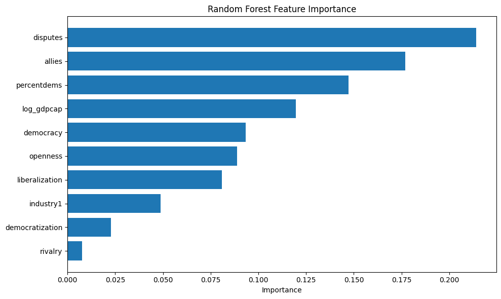

```python
#identify most important variables through feat
importances_df = pd.DataFrame({
    'Feature': X_train_smote.columns,
    'Importance': best_rf.feature_importances_
}).sort_values(by='Importance', ascending=False)

# Print top features
print(importances_df)

# Optional: Plot
plt.figure(figsize=(10, 6))
plt.barh(importances_df['Feature'], importances_df['Importance'])
plt.xlabel('Importance')
plt.title('Random Forest Feature Importance')
plt.gca().invert_yaxis()
plt.tight_layout()
plt.show()
```

# GBM Grid Search

```python
from xgboost import XGBClassifier
from sklearn.model_selection import GridSearchCV

# Define XGBoost model
xgb = XGBClassifier(use_label_encoder=False,
                    eval_metric='logloss',
                    random_state=2025)

# Hyperparameter grid
param_grid = {
    'n_estimators': list(range(100, 1001, 100)),  # number of trees
    'learning_rate': [0.01, 0.05, 0.1, 0.2],      # shrinkage
    'max_depth': [2, 4, 6, 8]                     # interaction depth
}

# Grid search
grid_search = GridSearchCV(
    estimator=xgb,
    param_grid=param_grid,
    cv=5,
    scoring='recall',  # or 'f1', 'accuracy', 'roc_auc'
    n_jobs=-1,
    verbose=1
)

# Fit on SMOTE-balanced training data
grid_search.fit(X_train_smote, y_train_smote)

# Best model
best_xgb = grid_search.best_estimator_

# Print best parameters
print("Best XGBoost params:", grid_search.best_params_)

# Evaluate on test set
evaluate_model("XGBoost (Tuned)", best_xgb, X_test, y_test)
```

```
Fitting 5 folds for each of 160 candidates, totalling 800 fits
```

[output not shown]

[output cut: 3149 more lines]

[output not shown]

```
Best XGBoost params: {'learning_rate': 0.05, 'max_depth': 4, 'n_estimators': 900}

XGBoost (Tuned) Evaluation:
Accuracy:    0.989
Precision:   0.286
Recall:      0.222
Specificity: 0.995
F1 Score:    0.250
No Information Rate: 0.992
```

### BART

```python
from ISLP.bart import BART
```

```python
bart_sw = BART(random_state=2025, burnin=5, ndraw=15)
bart_sw.fit(X_train_smote, y_train_smote)
```

```
BART(burnin=5, ndraw=15, random_state=2025)
```

Default prior is Inverse-Gamma(5, 0.9)

```python
var_inclusion = pd.Series(bart_sw.variable_inclusion_.mean(0),
                               index=X_train_smote.columns)
var_inclusion
```

0

[figure not shown]

Loading ITables v2.3.0 from the `init_notebook_mode` cell... (need [help](https://mwouts.github.io/itables/troubleshooting.html)?)